# Differences in Student Outcomes Between School Districts with Appointed Superintendents Versus Districts with Elected Superintendents

Owen Phillips

December 3, 2014

# 1 Background

My primary question is: Are there significant differences in student outcomes for school districts that have appointed or elected superintendents, controlling for demographic and socioeconomic variables at the district level? To answer this question I intend to utilize multiple regression analysis in order to properly compare school districts that have different demographic and socioeconomic characteristics.

# 2 Data Gathering

This paper is a cross section analysis of data from the 2013-14 academic school year. The data used in this analysis is the most recently published by the Mississippi Department of Education (MDE). Most of the data collected come directly from the MDE Office of Research and Statistics [website](http://ors.mde.k12.ms.us/). A small portion had to be obtained from the Office of Research and Statistics through [public records requests](http://ors.mde.k12.ms.us/Form.aspx). Additionally, the [Mississippi Parents Campaign](http://www.msparentscampaign.org/), the largest advocacy group supporting the abolishment of elected superintendents, provided the list of which districts have appointed or elected superintendents. Lastly, socioeconomic data was obtained via the [United States Census](http://www.census.gov/did/www/schooldistricts/data/). Lastly,enrollment data and the student-to-teacher ratio was obtained from the [National Center for Education Statistics](http://nces.ed.gov/) website.

The way the data is formatted is rather straightforward. The common link across all data sources is name of the school district. Unfortunately, in some instances the names of school districts are spelled differently across datasets (i.e. Greenwood Municipal School District vs. Greenwood City School Dist.). However, examples of this are rare.

One of the challenges in working with this data is that it comes from multiple sources. Normally when each observation (school district) is unique and formatted the same across all datasets, merging should be simple. However, in this case a few of the unique identifiers vary across datasets. In order to overcome this challenge I merged data sets according to the first 8 characters of each district name. This avoided the problem of districts that were labled differently (i.e. Greenwood Municipal School District vs. Greenwood City School Dist.). However, there were still two or three observations that required manual edits.

# 3 Defining the Data

| Variables | Explanation | Year | Source |
| --- | --- | --- | --- |
| Enrolled100s | Total District Enrollment (k-12) in 100s | 2014 | NCES |
| Student-to-Teacher Ratio | Ratio of students to teachers in the district | 2012 | NCES |
| Poverty Percentage | Percent of 5-17 year olds in poverty in the district | 2012 | 2012 Census |
| Graduation Rates | 2014 Graduation rate of the 2009 cohort | 2014 | MSDE |
| Composite Score | Composite score of all SATP tests | 2014 | MSDE |
| Mean Algebra | Average Algebra II SATP Test Scores | 2014 | MSDE |
| Mean Biology | Average Biology SATP Test Scores | 2014 | MSDE |
| Mean History | Average History SATP Test Scores | 2014 | MSDE |
| Mean English | Average English Test Scores | 2014 | MSDE |

The definitions of the variables used for this analysis are rather straightforward, regardless the following are formal definitions of the above variables and their justification for being included.

**Enrolled100s**: A continuous variable corresponding to the total number of students enrolled in grades K-12 in each district. Larger districts may be more difficult to manage from the superintendent’s perspective. Meanwhile, smaller districts may have an especially small talent pool to choose a qualified superintendent from. Including this variable in the analysis may shed some light on these questions.

**StudentTeacherRatio**: The ratio of students to teachers in the district. Previous studies have shown that lowering the student-to-teacher ratio can improve student performance.

**Poverty Percentage**: A variable ranging from 0% to 100% that describes the percentage of 5-17 year olds in the district that live under the federal poverty line. It has been well documented that poverty is detrimental to student outcomes and thus PovertyPct will control for socioeconomic differences between districts.

**Graduation Rates**: The percentage of students that were freshmen in 2009 that graduated by 2014. This is effectively the 5-year graduation rate.

**Composite Score**: A composite scores of all SATP test scores. The average of the Algebra II, Biology, History, and English scores may be more insightful than any one particular test.

**Mean Algebra**: Average test scores on the Algebra II SATP state test.

**Mean Biology**: Average test scores on the Biology SATP state test.

**Mean History**: Average test scores on the History SATP state test.

**Mean English**: Average test scores on the English SATP state test.

# 4 Descriptive Statistics

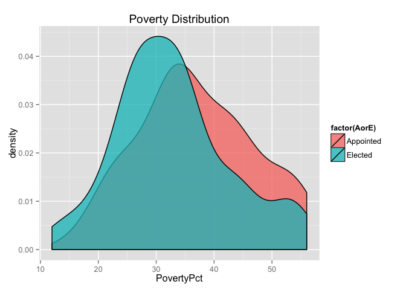

It may be easier to conceptualize the similarities between the two types of districts by examining density distributions of the aforementioned student outcomes. The following figures depict the density distributions for average Algebra II (Figure (5)), average Biology (Figure (6)), average English (Figure (7)), average History (Figure (8)), and average graduation rates (Figure (9)) for districts, delineated by whether they have an appointed or an elected superintendent. The distributions tell a fairly similar story to the descriptive statistics. At first glance, elected and appointed school districts are alike in regards to student outcomes. Considering the fact, it will be interesting to see whether this similarity holds after district characteristics (district enrollment, poverty, and student-to-teacher ratio) are controlled for.

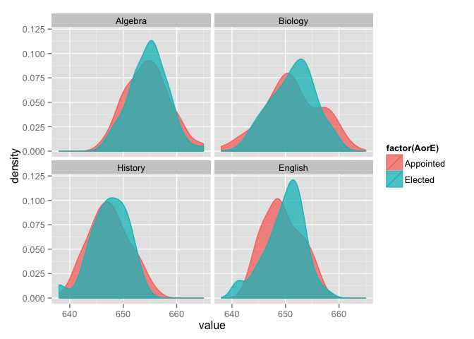

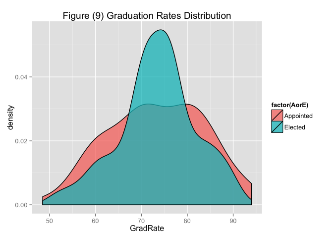

# 5 Regression Model

To assess the difference in student outcomes for the two types of districts I employed the use of regression analysis in order to control for certain observable characteristics that also impact student outcomes. The basic regression model is as follows:

**Y(i)[Student Outcome]** = **X0** + **X1(i)[Elected]** + **X2(i)[Enrolled100s]** + **X3(i)[Poverty Pct.]** + **X4(i)[Student-to-Teacher Ratio]** + **(X1(i) * X2(i))[Elected * Enrolled100s]** + **Eo**

Whereas **Y(i)[Student Outcome]** is the student outcome in the (i)th district. Student outcomes include the average Algebra II, Biology, U.S. History, and English SATP Test Scores in each district, a composite score of all SATP test scores in each district, and the 2009 cohort graduation rate;

Whereas **X1(i)[Elected]** is a dummy variable equal to 1 if the district has an elected superintendent;

Whereas **X2(i)[Enrolled100s]** is a continuous variable corresponding to the total number of students enrolled in grades K-12 in the (i)th district in 100s;

Whereas **X3(i)[Poverty Pct.]** is a variable ranging from 0 to 100 that describes the percentage of 5-17 year olds in the (i)th district that live under the federal poverty line;

Whereas **X4(i)[Student-to-Teacher Ratio]** is a continuous variable corresponding to the ratio of students to teachers in the (i)th district;

And whereas **(X1(i) * X2(i))[Elected * Enrolled100s]** is an interaction variable that allows the effect of having an elected superintendent to vary alongside the total enrollment in the (i)th district. If elected superintendents are detrimental to student outcomes than we would expect the sign on **X1(i)[Elected]** to be negative. More specifically, we’d expect the combined effect of **X1(i)[Elected]** and **(X1(i) * X2(i))[Elected * Total Enrollment]** to be negative.

# 6 Regression Results

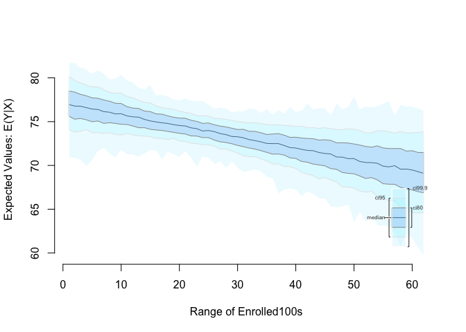

Refrences